# Altmetric Articles

2018-07-24

# Article data

The *article* is the master Altmetric entity, and contains all the basic information about title, publication date, the first author etc, as well as summaries, such as the numbers of mentions, the altmetric scores and so on.

Most of the fun to be had with article data is achieved by joining it to other datasets, but how to do so and what can be achieved are described in the notebooks for those datasets. See the Notebook_Subjects.rmd for an example.

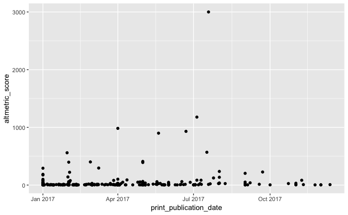

```r
ggplot(data = articles) +
  geom_point(mapping = aes(
    x = print_publication_date,
    y = altmetric_score
    ))
```

## Article data dictionary

Articles have the following fields:

### altmetric_id

An article identifier used internally by Altmetric themselves, but included here in case there are reasons to contact Altmetric about anything that looks odd.

### altmetric_journal_id

**Data type: character**

A unique id for the journal assigned by altmetric. For clarity it is better to include journal_title in a grouping statement, as sometimes the journals returned haven’t been assigned a corresponding altmetric_journal_id (e.g. for DOI 10.18408/ahuri-5308301 in our test set).

```r
arrange(
  summarise(
    group_by(articles,
             journal_title,
             altmetric_journal_id
    ),
    total_articles = n()
  ),
  desc(total_articles)
)
```

| journal_title | altmetric_journal_id | total_articles |
| --- | --- | --- |
| Social Science & Medicine | 4f6fa6383cf058f610008969 | 12 |
| Review of Higher Education | 4f6fa5133cf058f61000347f | 10 |
| Diabetes Care | 4f6fa4eb3cf058f6100026f8 | 8 |
| Comunicar | 4f6fa5223cf058f610003ad5 | 7 |
| Journal of Innovation in Health Informatics | 56b368412a83ee42788b4674 | 7 |
| American Economic Review | 4f6fa4dc3cf058f610001967 | 6 |
| Health Affairs | 4f6fa4ec3cf058f6100029ba | 5 |
| American Journal of Respiratory & Critical Care Medicine | 4f6fa5e53cf058f610005716 | 4 |
| Journal of Economic Perspectives | 4f6fa4dc3cf058f6100018c5 | 4 |
| MMWR: Morbidity & Mortality Weekly Report | 4f6fa5063cf058f6100030f9 | 4 |

[output cut: 207 more lines]

### altmetric_score

**Data type: numeric**

The score altmetric gives to articles depending upon the amount of attention they have received. This is [described in more detail by Altmetric themselves](https://help.altmetric.com/support/solutions/articles/6000059309-about-altmetric-and-the-altmetric-attention-score). The Altmetric Client also outputs a much more detailed scores dataset which is covered by the Notebook_Scores.Rmd file.

```r
arrange(select(articles,
               article_title,
               first_author,
               altmetric_score),
        desc(altmetric_score))
```

```
# A tibble: 325 x 3
   article_title                          first_author    altmetric_score
   <chr>                                  <chr>                     <dbl>
 1 Dementia prevention, intervention, an… Gill Livingston           3000.
 2 Higher Education funding in England: … Chris Belfield            1178.
 3 Evolution and patterns of global heal… Dieleman, Jose…            983.
 4 The Impact of Whole-Genome Sequencing… Vassy, Jason L.            931.
 5 Three-Year Impacts Of The Affordable … Benjamin D. So…            899.
 6 Financing transformative health syste… Karin Stenberg             569.
 7 Global economic cost of smoking-attri… Mark Goodchild             560.
 8 Machine Learning: An Applied Economet… Mullainathan, …            409.
 9 Long-run comparisons of spending per … Chris Belfield             401.
10 The health and economic implications … Waters, Hugh R.            397.
# ... with 315 more rows
```

### article_title

**Data type: character**

The (often very long - go figure) title of the article.

### doi (Digital Object Identifier)

**Data type: character**

In the current version of the Altmetric client the DOI is the primary identifier, and is the method used to retrieve Altmetric data from the API. Very nearly all joins between datasets are achieved using the doi field (the exception being the join between mentions and authors).

### journal_title

**Data type: character**

The title of the journal. Grouping by this field enables finding out which is the most commonly journal in your overall dataset.

```r
arrange(
  summarise(
    group_by(articles,
             journal_title
    ),
    total_articles = n()
  ),
  desc(total_articles)
)
```

```
# A tibble: 216 x 2
   journal_title                                            total_articles
   <chr>                                                             <int>
 1 Social Science & Medicine                                            12
 2 Review of Higher Education                                           10
 3 Diabetes Care                                                         8
 4 Comunicar                                                             7
 5 Journal of Innovation in Health Informatics                           7
 6 American Economic Review                                              6
 7 Health Affairs                                                        5
 8 American Journal of Respiratory & Critical Care Medicine              4
 9 Journal of Economic Perspectives                                      4
10 MMWR: Morbidity & Mortality Weekly Report                             4
# ... with 206 more rows
```

### journal_volume

**Data type: character**

The volume of the journal that the article is in (if known - this is quite patchy information).

### journal_issue

**Data type: character**

The issue of the journal that the article is in (again, often unrecorded).

### page_starts

**Data type: character**

The page the article starts on (if known, again patchy).

### page_ends

**Data type: character**

The page the article ends

### print_publication_date

**Data type: POSIX Calendar Time**

The best attempt at establishing the date an article was published *in print*. This is obviously getting less and less relevant by the minute, as more and more articles are published online first. This becomes evident when you run queries to establish the length of time *after* publication before the first mention, and find hundreds of instances where the article was mentioned before it was published. See our [analysis of the impact of Open Access on policy] (https://github.com/CamLib/OAPolicyDataAnalysis) for some examples of this.

### publisher

**Data type: character**

The publisher of the article. Like journal_title, this enables grouping and counts of publisher popularity in the set. Unlike journal_title, however, this information is often unknown.

```r
arrange(
  summarise(
    group_by(articles,
             publisher
    ),
    total_articles = n()
  ),
  desc(total_articles)
)
```

```
# A tibble: 72 x 2
   publisher                          total_articles
   <chr>                                       <int>
 1 <NA>                                          112
 2 Elsevier BV                                    15
 3 BioMed Central                                 14
 4 Oxford University Press                        12
 5 Routledge                                      12
 6 Taylor & Francis                               11
 7 The Johns Hopkins University Press             10
 8 American Diabetes Association                   9
 9 American Economic Association                   8
10 Elsevier                                        8
# ... with 62 more rows
```

### total_mentions

**Data type: int**

Summarises the total number of mentions. Altmetric themselves provide this summary field via their, though the same can be achieved by joining the articles to the mentions dataset (see Notebook_Mentions.Rmd). The latter approach further enables filtering / grouping by mention source (e.g. ‘most mentioned on Twitter, in the news, in policy documentation’ etc).

```r
arrange(
  select(
    articles,
    article_title,
    total_mentions
  ),
  desc(total_mentions)
)
```

```
# A tibble: 325 x 2
   article_title                                                                 total_mentions
   <chr>                                                                                  <int>
 1 Higher Education funding in England: past, present and options for the future           1572
 2 Dementia prevention, intervention, and care                                             1480
 3 Three-Year Impacts Of The Affordable Care Act: Improved Medical Care And Hea…            982
 4 Financing transformative health systems towards achievement of the health Su…            731
 5 Evolution and patterns of global health financing 1995–2014: development ass…            689
 6 Machine Learning: An Applied Econometric Approach                                        541
 7 Long-run comparisons of spending per pupil across different stages of educat…            474
 8 Global economic cost of smoking-attributable diseases                                    403
 9 Integration of Palliative Care Into Standard Oncology Care: American Society…            384
10 The Impact of Whole-Genome Sequencing on the Primary Care and Outcomes of He…            298
# ... with 315 more rows
```

### type

**Data type: character**

This is a category determined by Altmetric themselves, and appears to always be ‘article’.

```r
  summarise(group_by(articles, type), total = n())
```

```
# A tibble: 1 x 2
  type    total
  <chr>   <int>
1 article   325
```